# Overview

**Overview**

Dataset statistics

| Number of variables | 12 |
| --- | --- |
| Number of observations | 891 |
| Missing cells | 866 |
| Missing cells (%) | 8.1% |
| Duplicate rows | 0 |
| Duplicate rows (%) | 0.0% |
| Total size in memory | 315.0 KiB |
| Average record size in memory | 362.1 B |

Variable types

| Numeric | 5 |
| --- | --- |
| Categorical | 7 |

**Alerts 21**

| `Name` has a high cardinality: 891 distinct values | High cardinality |
| --- | --- |
| `Ticket` has a high cardinality: 681 distinct values | High cardinality |
| `Cabin` has a high cardinality: 147 distinct values | High cardinality |
| `Pclass` is highly correlated with `Fare` and 1 other fields | High correlation |
| `Fare` is highly correlated with `Pclass` | High correlation |
| `Sex` is highly correlated with `Survived` | High correlation |
| `Survived` is highly correlated with `Sex` | High correlation |
| `SibSp` is highly correlated with `Parch` | High correlation |
| `Parch` is highly correlated with `SibSp` | High correlation |
| `Embarked` is highly correlated with `Pclass` | High correlation |
| `Age` has 177 (19.9%) missing values | Missing |
| `Cabin` has 687 (77.1%) missing values | Missing |
| `PassengerId` is uniformly distributed | Uniform |
| `Name` is uniformly distributed | Uniform |
| `Ticket` is uniformly distributed | Uniform |
| `Cabin` is uniformly distributed | Uniform |
| `PassengerId` has unique values | Unique |
| `Name` has unique values | Unique |
| `SibSp` has 608 (68.2%) zeros | Zeros |
| `Parch` has 678 (76.1%) zeros | Zeros |
| `Fare` has 15 (1.7%) zeros | Zeros |

**Reproduction**

Reproduction

| Analysis started | 2022-09-27 03:45:25.117322 |
| --- | --- |
| Analysis finished | 2022-09-27 03:45:26.527233 |
| Duration | 1.41 second |
| Software version | [pandas-profiling v3.3.0](https://github.com/pandas-profiling/pandas-profiling) |
| Download configuration | config.json |

# Variables

PassengerId  
Real number (ℝ<sub>≥0</sub>)

`UNIFORM`  
`UNIQUE`

| Distinct | 891 |
| --- | --- |
| Distinct (%) | 100.0% |
| Missing | 0 |
| Missing (%) | 0.0% |
| Infinite | 0 |
| Infinite (%) | 0.0% |
| Mean | 446 |

| Minimum | 1 |
| --- | --- |
| Maximum | 891 |
| Zeros | 0 |
| Zeros (%) | 0.0% |
| Negative | 0 |
| Negative (%) | 0.0% |
| Memory size | 7.1 KiB |

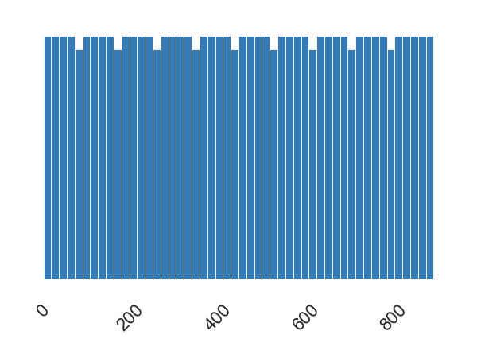

**Statistics**

Quantile statistics

| Minimum | 1 |
| --- | --- |
| 5-th percentile | 45.5 |
| Q1 | 223.5 |
| median | 446 |
| Q3 | 668.5 |
| 95-th percentile | 846.5 |
| Maximum | 891 |
| Range | 890 |
| Interquartile range (IQR) | 445 |

Descriptive statistics

| Standard deviation | 257.353842 |
| --- | --- |
| Coefficient of variation (CV) | 0.5770265516 |
| Kurtosis | -1.2 |
| Mean | 446 |
| Median Absolute Deviation (MAD) | 223 |
| Skewness | 0 |
| Sum | 397386 |
| Variance | 66231 |
| Monotonicity | Strictly increasing |

**Histogram**

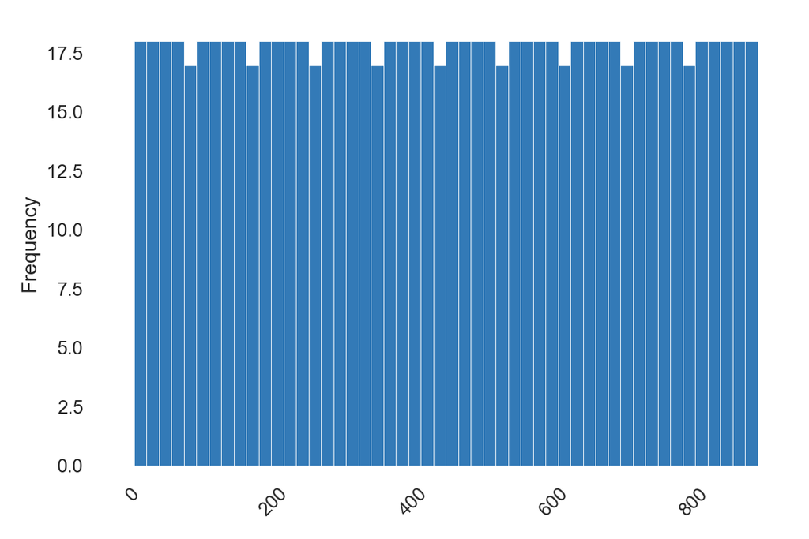

**Histogram with fixed size bins** (bins=50)

**Common values**

| Value | Count | Frequency (%) |
| --- | --- | --- |
| 1 | 1 | 0.1% |
| 599 | 1 | 0.1% |
| 588 | 1 | 0.1% |
| 589 | 1 | 0.1% |
| 590 | 1 | 0.1% |
| 591 | 1 | 0.1% |
| 592 | 1 | 0.1% |
| 593 | 1 | 0.1% |
| 594 | 1 | 0.1% |
| 595 | 1 | 0.1% |
| Other values (881) | 881 | 98.9% |

**Extreme values**

**Minimum 10 values**

| Value | Count | Frequency (%) |
| --- | --- | --- |
| 1 | 1 | 0.1% |
| 2 | 1 | 0.1% |
| 3 | 1 | 0.1% |
| 4 | 1 | 0.1% |
| 5 | 1 | 0.1% |
| 6 | 1 | 0.1% |
| 7 | 1 | 0.1% |
| 8 | 1 | 0.1% |
| 9 | 1 | 0.1% |
| 10 | 1 | 0.1% |

**Maximum 10 values**

| Value | Count | Frequency (%) |
| --- | --- | --- |
| 891 | 1 | 0.1% |
| 890 | 1 | 0.1% |
| 889 | 1 | 0.1% |
| 888 | 1 | 0.1% |
| 887 | 1 | 0.1% |
| 886 | 1 | 0.1% |
| 885 | 1 | 0.1% |
| 884 | 1 | 0.1% |
| 883 | 1 | 0.1% |
| 882 | 1 | 0.1% |

Survived  
Categorical

`HIGH CORRELATION`

| Distinct | 2 |
| --- | --- |
| Distinct (%) | 0.2% |
| Missing | 0 |
| Missing (%) | 0.0% |
| Memory size | 50.6 KiB |

| 0 | 549 |
| --- | --- |
| 1 | 342 |

**Overview**

Length

| Max length | 1 |
| --- | --- |
| Median length | 1 |
| Mean length | 1 |
| Min length | 1 |

Characters and Unicode

| Total characters | 891 |
| --- | --- |
| Distinct characters | 2 |
| Distinct categories | 1 [?](https://en.wikipedia.org/wiki/Unicode_character_property#General_Category) |
| Distinct scripts | 1 ? |
| Distinct blocks | 1 [?](https://en.wikipedia.org/wiki/Unicode_block) |

The Unicode Standard assigns character properties to each code point, which can be used to analyse textual variables.

Unique

| Unique | 0 ? |
| --- | --- |
| Unique (%) | 0.0% |

Sample

| 1st row | 0 |
| --- | --- |
| 2nd row | 1 |
| 3rd row | 1 |
| 4th row | 1 |
| 5th row | 0 |

**Categories**